# Логические методы классификации

## Библиотеки

```python
import matplotlib.pyplot as plt
from matplotlib.image import imread
from mpl_toolkits import mplot3d
from matplotlib import gridspec
from copy import deepcopy
from mlxtend.plotting import plot_decision_regions
import seaborn as sns
import pandas as pd
from tqdm.notebook import tqdm
from scipy.special import softmax
from scipy.spatial.distance import cdist
import numpy as np
from sklearn import tree
import itertools
from sklearn.tree import DecisionTreeClassifier, DecisionTreeRegressor
from sklearn.ensemble import RandomForestClassifier
from sklearn.preprocessing import StandardScaler
from sklearn.svm import SVC, SVR
from sklearn.linear_model import LogisticRegression
from sklearn.metrics import classification_report, roc_auc_score, roc_curve
from sklearn.metrics import auc
from sklearn.model_selection import KFold, ParameterGrid
from sklearn.datasets import make_classification, load_wine, load_boston
from sklearn.model_selection import train_test_split
from sklearn.decomposition import PCA
from torchvision import datasets
from torchvision import transforms
```

## Логические классификаторы

Рассмотрим простой логический классификатор вида: $$ R(x) = \wedge_{{j \in J}} \left[a_j \leq x_j \leq b_j\right] $$

Далее выполнена простая реализация метода для поиска логических закономерностей. Метод работает на основе алгоритма предложенного на лекции:

1. На вход принимается выборка X, Y
2. Составляется начальное множество $Z$ правил вида $R(x)$
3. Заданое количество раз выполняем случайные локальные модификации правил $R\in Z$
4. На каждом шаге выполняем отсеивание лучших правил на основе accuracy
5. После заданого количества шагов выбираем лучший критерий на основе accuracy

P.S. В качестве домашнего задания будет улучшить алгоритм из семинара: рассмотреть критерий Джини вместо accuracy.

### Простые Гаусианы

```python
np.random.seed(0)
l = 150
n = 2
X1 = np.array([[-1,-1] + [0]*(n-2)]) + 0.6*np.random.randn(l, n)
X2 = np.array([[1,1] + [0]*(n-2)]) + 0.6*np.random.randn(l, n)

X = np.vstack([X1, X2])
Y = np.hstack([[0]*l, [1]*l])

X_train, X_test, Y_train, Y_test = train_test_split(X, Y,
                                                    test_size=50,
                                                    random_state=0)
```

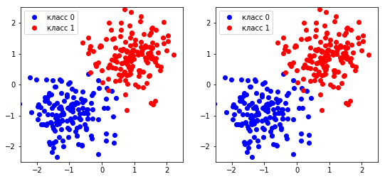

```python
cols = ['blue', 'red', 'green']
fig, gs = plt.figure(figsize=(9,4)), gridspec.GridSpec(1, 2)

ax = []
for i in range(2):
    ax.append(fig.add_subplot(gs[i]))
    ax[i].set_xlim((-2.5, 2.5)), ax[i].set_ylim((-2.5, 2.5))

for k in np.unique(Y):
    ax[0].plot(X[Y==k,0], X[Y==k,1], 'o',
               label='класс {}'.format(k), color=cols[k])
    ax[1].plot(X[Y==k,0], X[Y==k,1], 'o',
               label='класс {}'.format(k), color=cols[k])

ax[0].legend(loc='best'), ax[1].legend(loc='best')
plt.show()
```

```python
model = LogicClassifier(max_iter=1000)
print(model)
print(model.fit(X_train, Y_train, seed=0))
print(model.score(X_train, Y_train), model.score(X_test, Y_test))
print(classification_report(Y_test, model.predict(X_test)))
```

```
R(x) = 1
R(x) = 0.16 < x_0 < 1.95 AND -0.94 < x_1 < 2.65
0.924 0.9
              precision    recall  f1-score   support

           0       0.86      0.96      0.91        25
           1       0.95      0.84      0.89        25

    accuracy                           0.90        50
   macro avg       0.91      0.90      0.90        50
weighted avg       0.91      0.90      0.90        50
```

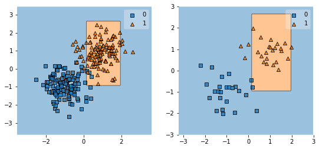

```python
fig, gs = plt.figure(figsize=(9,4)), gridspec.GridSpec(1, 2)

ax = []
for i in range(2):
    ax.append(fig.add_subplot(gs[i]))

plot_decision_regions(X_train, Y_train, model, ax=ax[0])
plot_decision_regions(X_test, Y_test, model, ax=ax[1])

plt.show()
```

### Посложнее выборка

```python
X, Y = make_classification(n_samples=150, n_features=2,
                           n_informative=2, n_classes=2,
                           n_redundant=0,
                           n_clusters_per_class=1,
                           random_state=0)

X_train, X_test, Y_train, Y_test = train_test_split(X, Y,
                                                    test_size=50,
                                                    random_state=0)
```

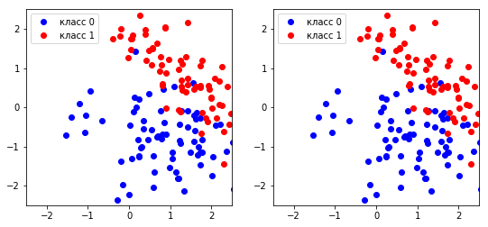

```python
cols = ['blue', 'red', 'green']
fig, gs = plt.figure(figsize=(9,4)), gridspec.GridSpec(1, 2)

ax = []
for i in range(2):
    ax.append(fig.add_subplot(gs[i]))
    ax[i].set_xlim((-2.5, 2.5)), ax[i].set_ylim((-2.5, 2.5))

for k in np.unique(Y):
    ax[0].plot(X[Y==k,0], X[Y==k,1], 'o',
               label='класс {}'.format(k), color=cols[k])
    ax[1].plot(X[Y==k,0], X[Y==k,1], 'o',
               label='класс {}'.format(k), color=cols[k])

ax[0].legend(loc='best'), ax[1].legend(loc='best')
plt.show()
```

```python
model = LogicClassifier(max_iter=1000)
print(model)
print(model.fit(X_train, Y_train, seed=0))
print(model.score(X_train, Y_train), model.score(X_test, Y_test))
print(classification_report(Y_test, model.predict(X_test)))
```

```
R(x) = 1
R(x) = 0.67 < x_1 < 2.41 AND -1.53 < x_0 < 2.67
0.71 0.8
              precision    recall  f1-score   support

           0       0.73      1.00      0.84        27
           1       1.00      0.57      0.72        23

    accuracy                           0.80        50
   macro avg       0.86      0.78      0.78        50
weighted avg       0.85      0.80      0.79        50
```

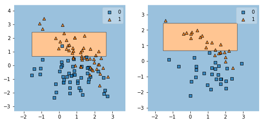

```python
fig, gs = plt.figure(figsize=(9,4)), gridspec.GridSpec(1, 2)

ax = []
for i in range(2):
    ax.append(fig.add_subplot(gs[i]))

plot_decision_regions(X_train, Y_train, model, ax=ax[0])
plot_decision_regions(X_test, Y_test, model, ax=ax[1])

plt.show()
```

### Выборка Wine

```python
data = load_wine()
X = data['data']
Y = data['target']

X = X[Y < 2]
Y = Y[Y < 2]

X_train, X_test, Y_train, Y_test = train_test_split(X, Y,
                                                    test_size=30,
                                                    random_state=0)
```

```python
model = LogicClassifier(max_iter=1000)
print(model)
print(model.fit(X_train, Y_train, seed=0))
print(model.score(X_train, Y_train), model.score(X_test, Y_test))
print(classification_report(Y_test, model.predict(X_test)))
```

```
R(x) = 1
R(x) = -0.97 < x_5 < 2.25
0.77 0.7333333333333333
              precision    recall  f1-score   support

           0       0.67      1.00      0.80        16
           1       1.00      0.43      0.60        14

    accuracy                           0.73        30
   macro avg       0.83      0.71      0.70        30
weighted avg       0.82      0.73      0.71        30
```

## Критерии Информативности

1. энтропийный критерий: $$ IGain\bigr(p, n\bigr) = h\bigr(\frac{P}{l}\bigr) - \frac{p+n}{l}h\bigr(\frac{p}{p+n}\bigr) - \frac{l-p-n}{l}h\bigr(\frac{P-p}{l-p-n}\bigr), $$ где $h\bigr(q\bigr)=-q\log_2 q - \bigr(1-q\bigr)\log_2\bigr(1-q\bigr)$.
2. критерий Джини: $$ IGini\bigr(p,n\bigr) = IGain\bigr(p,n\bigr), \quad h\bigr(q\bigr)=4q\left(1-q\right) $$
3. критерий бутинга: $$ BC\bigr(p, n\bigr) = \sqrt{p} - \sqrt{n} $$

## Ансамблирование правил

1. Как видно было раньше, логические правила позволяют выделять одну область.
2. Но как было показано выше, в большинстве случаев этого не достаточно.
3. Для покрытия нескольких областей используем компизицию логических правил.

Простые решения:

1. Взвешенное голосование
2. Простое голосование
3. Решающий список

### Простой алгоритм для построения решающего списка

```python
np.random.seed(0)
l = 150
n = 2
X1 = np.array([[-1,-1] + [0]*(n-2)]) + 0.6*np.random.randn(l, n)
X2 = np.array([[1,1] + [0]*(n-2)]) + 0.6*np.random.randn(l, n)

X = np.vstack([X1, X2])
Y = np.hstack([[0]*l, [1]*l])

X_train, X_test, Y_train, Y_test = train_test_split(X, Y,
                                                    test_size=50,
                                                    random_state=0)
```

```python
model = LogicClassifier(max_iter=1000)
print(model)
print(model.fit(X_train, Y_train, seed=0))
print(model.score(X_train, Y_train), model.score(X_test, Y_test))
print(classification_report(Y_test, model.predict(X_test)))
```

```
R(x) = 1
R(x) = 0.16 < x_0 < 1.95 AND -0.94 < x_1 < 2.65
0.924 0.9
              precision    recall  f1-score   support

           0       0.86      0.96      0.91        25
           1       0.95      0.84      0.89        25

    accuracy                           0.90        50
   macro avg       0.91      0.90      0.90        50
weighted avg       0.91      0.90      0.90        50
```

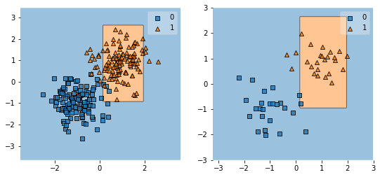

```python
fig, gs = plt.figure(figsize=(9,4)), gridspec.GridSpec(1, 2)

ax = []
for i in range(2):
    ax.append(fig.add_subplot(gs[i]))

plot_decision_regions(X_train, Y_train, model, ax=ax[0])
plot_decision_regions(X_test, Y_test, model, ax=ax[1])

plt.show()
```

```python
model = LogicClassifierCommittee(max_iter=1000)
print(model)
print(model.fit(X_train, Y_train, seed=0))
print(model.score(X_train, Y_train), model.score(X_test, Y_test))
print(classification_report(Y_test, model.predict(X_test)))
```

```
R(x) = 1
R(x) = (0.16 < x_0 < 1.95 AND -0.94 < x_1 < 2.65) OR (0.9 < x_1 < 2.23)
0.972 0.96
              precision    recall  f1-score   support

           0       0.96      0.96      0.96        25
           1       0.96      0.96      0.96        25

    accuracy                           0.96        50
   macro avg       0.96      0.96      0.96        50
weighted avg       0.96      0.96      0.96        50
```

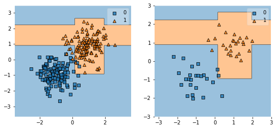

```python
fig, gs = plt.figure(figsize=(9,4)), gridspec.GridSpec(1, 2)

ax = []
for i in range(2):
    ax.append(fig.add_subplot(gs[i]))

plot_decision_regions(X_train, Y_train, model, ax=ax[0])
plot_decision_regions(X_test, Y_test, model, ax=ax[1])

plt.show()
```

## Деревья

```python
np.random.seed(0)
l = 150
n = 2
X1 = np.array([[-1,-1] + [0]*(n-2)]) + 0.6*np.random.randn(l, n)
X2 = np.array([[1,1] + [0]*(n-2)]) + 0.6*np.random.randn(l, n)

X = np.vstack([X1, X2])
Y = np.hstack([[0]*l, [1]*l])

X_train, X_test, Y_train, Y_test = train_test_split(X, Y,
                                                    test_size=50,
                                                    random_state=0)
```

```python
model = DecisionTreeClassifier(max_depth=2, random_state=0)
model.fit(X_train, Y_train)
print(model.score(X_train, Y_train), model.score(X_test, Y_test))
print(classification_report(Y_test, model.predict(X_test)))
```

```
0.984 0.98
              precision    recall  f1-score   support

           0       1.00      0.96      0.98        25
           1       0.96      1.00      0.98        25

    accuracy                           0.98        50
   macro avg       0.98      0.98      0.98        50
weighted avg       0.98      0.98      0.98        50
```

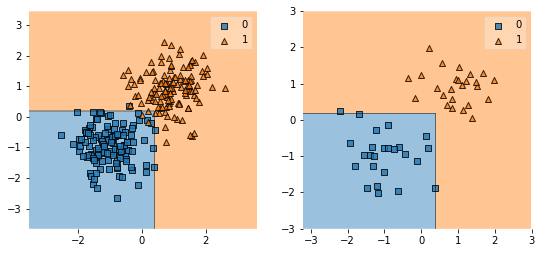

```python
fig, gs = plt.figure(figsize=(9,4)), gridspec.GridSpec(1, 2)

ax = []
for i in range(2):
    ax.append(fig.add_subplot(gs[i]))

plot_decision_regions(X_train, Y_train, model, ax=ax[0])
plot_decision_regions(X_test, Y_test, model, ax=ax[1])

plt.show()
```

```python
text_representation = tree.export_text(model)
print(text_representation)
```

```
|--- feature_1 <= 0.18
|   |--- feature_0 <= 0.40
|   |   |--- class: 0
|   |--- feature_0 >  0.40
|   |   |--- class: 1
|--- feature_1 >  0.18
|   |--- feature_0 <= -0.38
|   |   |--- class: 1
|   |--- feature_0 >  -0.38
|   |   |--- class: 1
```

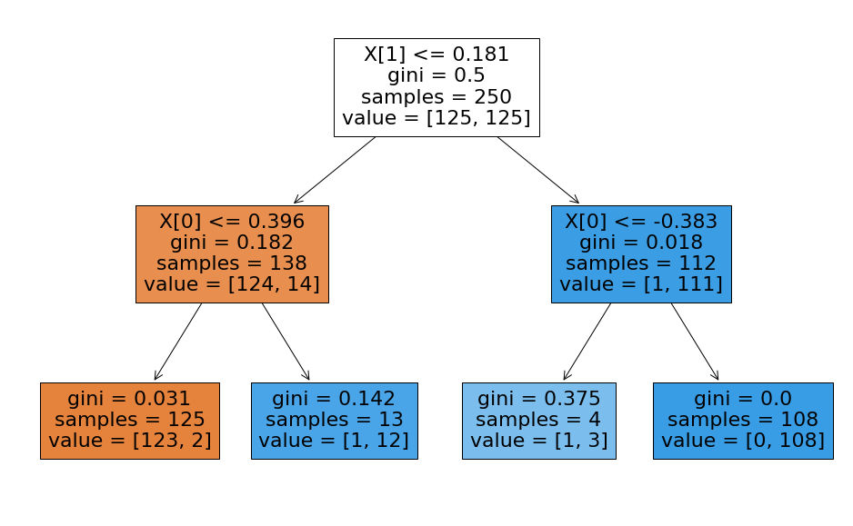

```python
fig = plt.figure(figsize=(16,10))
_ = tree.plot_tree(model, filled=True)
```

### Посмотрим как область зависит от глубины деревав

```python
models = []
for depth in range(1, 5):
    model = DecisionTreeClassifier(max_depth=depth, random_state=0)
    model.fit(X_train, Y_train)
    models.append(model)
```

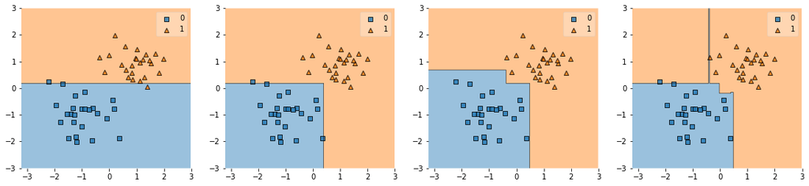

```python
fig, gs = plt.figure(figsize=(19, 4)), gridspec.GridSpec(1, 4)

ax = []
for i in range(4):
    ax.append(fig.add_subplot(gs[i]))

for i, model in enumerate(models):
    plot_decision_regions(X_test, Y_test, model, ax=ax[i])

plt.show()
```

### Выборка Wine

```python
data = load_wine()
X = data['data']
Y = data['target']

X_train, X_test, Y_train, Y_test = train_test_split(X, Y,
                                                    test_size=30,
                                                    random_state=0)
```

```python
model = DecisionTreeClassifier(max_depth=2, random_state=0)
model.fit(X_train, Y_train)
print(model.score(X_train, Y_train), model.score(X_test, Y_test))
print(classification_report(Y_test, model.predict(X_test)))
```

```
0.9391891891891891 0.7666666666666667
              precision    recall  f1-score   support

           0       0.64      1.00      0.78         9
           1       1.00      0.53      0.70        15
           2       0.75      1.00      0.86         6

    accuracy                           0.77        30
   macro avg       0.80      0.84      0.78        30
weighted avg       0.84      0.77      0.75        30
```

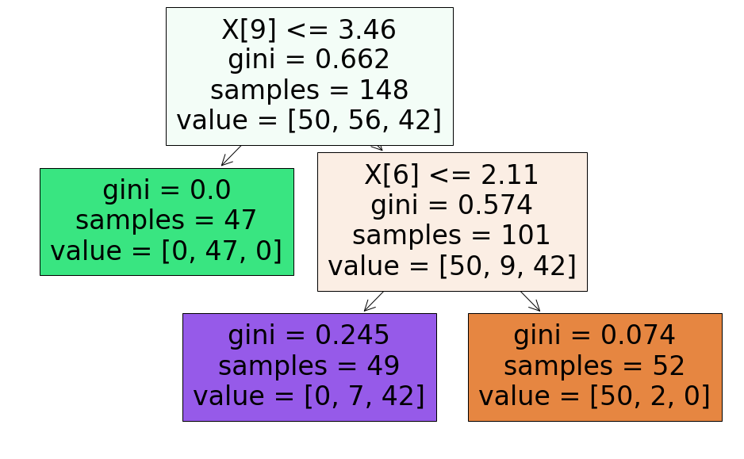

```python
fig = plt.figure(figsize=(16,10))
_ = tree.plot_tree(model, filled=True)
```

### Выборка Boston

```python
data = load_boston()
X = data['data']
Y = data['target']

X_train, X_test, Y_train, Y_test = train_test_split(X, Y,
                                                    test_size=30,
                                                    random_state=0)
```

```python
model = DecisionTreeRegressor(max_depth=3, random_state=0)
model.fit(X_train, Y_train)
print(model.score(X_train, Y_train), model.score(X_test, Y_test))
```

```
0.8154635751352297 0.8398735739316583
```

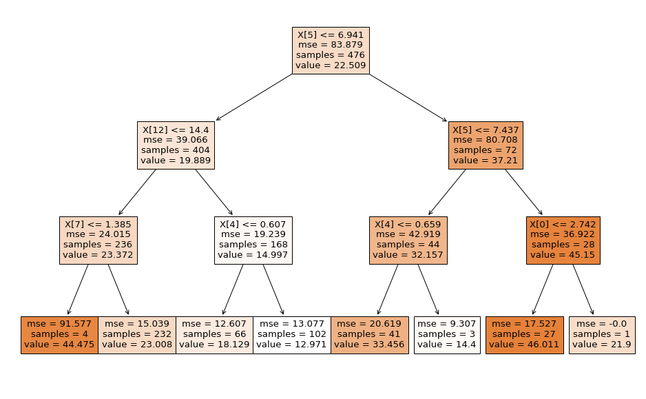

```python
fig = plt.figure(figsize=(16,10))
_ = tree.plot_tree(model, filled=True)
```

### Пример на синтетичеких одномерных данных

```python
np.random.seed(0)
l = 200
beta = 1.

X = np.linspace(-10, 10, l).reshape([-1, 1])
w = np.array([1., 1., 4.,])
Y = w[0] + w[1]*X[:, 0] + w[2]*np.sin(X[:, 0]) + beta*np.random.randn(l)

X_train, X_test, Y_train, Y_test = train_test_split(X, Y, test_size=50)
```

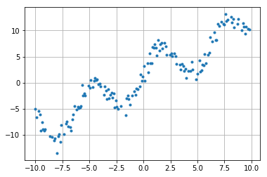

```python
plt.plot(X_train[:, 0], Y_train, '.')

plt.grid()
plt.show()
```

```python
model = DecisionTreeRegressor(max_depth=3, random_state=0)
model.fit(X_train, Y_train)
print(model.score(X_train, Y_train), model.score(X_test, Y_test))
```

```
0.9460287810405261 0.9478218965668251
```

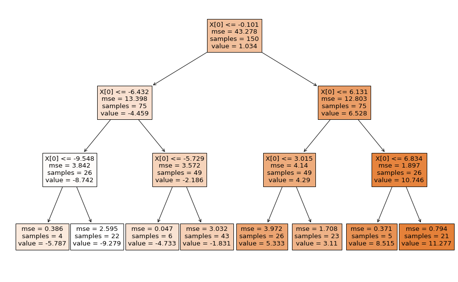

```python
fig = plt.figure(figsize=(16,10))
_ = tree.plot_tree(model, filled=True)
```

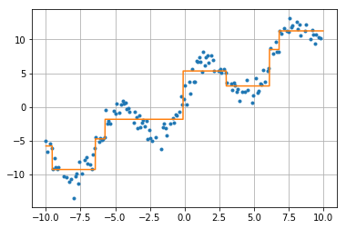

```python
plt.plot(X_train[:, 0], Y_train, '.')

x = np.linspace(-10, 10, 2000)

plt.plot(x, model.predict(x.reshape(-1,1)))

plt.grid()
plt.show()
```

### Зависимость от глубины дерева

```python
models = []
for i in [3, 5, 9]:
    model = DecisionTreeRegressor(max_depth=i, random_state=0)
    model.fit(X_train, Y_train)
    models.append(model)
```

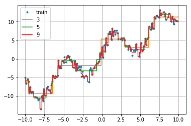

```python
plt.plot(X_train[:, 0], Y_train, '.', label='train')

x = np.linspace(-10, 10, 2000)
for model in models:
    plt.plot(x, model.predict(x.reshape(-1,1)), label=str(model.get_depth()))

plt.legend(loc='best')
plt.grid()
plt.show()
```

### Случайный лес

В данном случае мы говорим о множестве решающих деревьев (отсюда и слово лес).

1. Для задачи классификации в листях деревьев лежит класс.
2. Для задачи регресии в листях лежит среднее значение ответов для всех объектов.

Случайный лес является ансамблем деревьев:

1. Для каждого дерева выбирается произвольное подмножество объектов.
2. Строится каждое дерево не завиимо друг от друга.

```python
data = load_wine()
X = data['data']
Y = data['target']

X_train, X_test, Y_train, Y_test = train_test_split(X, Y,
                                                    test_size=30,
                                                    random_state=0)
```

```python
model = RandomForestClassifier(n_estimators=6, max_depth=2, random_state=0)
model.fit(X_train, Y_train)
print(model.score(X_train, Y_train), model.score(X_test, Y_test))
print(classification_report(Y_test, model.predict(X_test)))
```

```
0.9797297297297297 0.9666666666666667
              precision    recall  f1-score   support

           0       1.00      1.00      1.00         9
           1       1.00      0.93      0.97        15
           2       0.86      1.00      0.92         6

    accuracy                           0.97        30
   macro avg       0.95      0.98      0.96        30
weighted avg       0.97      0.97      0.97        30
```

### Зависимость качества от числа деревьев

```python
models = []
scores_train = []
scores_test = []
n_estimators = list(range(1, 20))
for estimators in n_estimators:
    model = RandomForestClassifier(n_estimators=estimators, random_state=0)
    model.fit(X_train, Y_train)
    models.append(model)
    scores_test.append(model.score(X_test, Y_test))
    scores_train.append(model.score(X_train, Y_train))
```

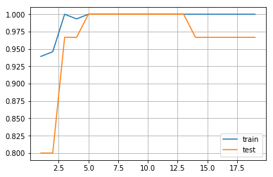

```python
plt.plot(n_estimators, scores_train, label='train')
plt.plot(n_estimators, scores_test, label='test')

plt.legend(loc='best')
plt.grid()
plt.show()
```

### Зависимость качества от числа признаков при расщеплении

```python
models = []
scores_train = []
scores_test = []
max_features = list(range(1, 13))
for features in max_features:
    model = RandomForestClassifier(n_estimators=6,
                                   max_features=features, random_state=0)
    model.fit(X_train, Y_train)
    models.append(model)
    scores_test.append(model.score(X_test, Y_test))
    scores_train.append(model.score(X_train, Y_train))
```

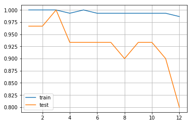

```python
plt.plot(max_features, scores_train, label='train')
plt.plot(max_features, scores_test, label='test')

plt.legend(loc='best')
plt.grid()
plt.show()
```

### Зависимость качества от глубины деревьев

```python
models = []
scores_train = []
scores_test = []
current_depth = []
max_depth = list(range(1, 10))
for depth in max_depth:
    model = RandomForestClassifier(n_estimators=6,
        max_depth=depth, random_state=0)
    model.fit(X_train, Y_train)
    models.append(model)
    scores_test.append(model.score(X_test, Y_test))
    scores_train.append(model.score(X_train, Y_train))
    current_depth.append(model.estimators_[0].get_depth()/depth)
```

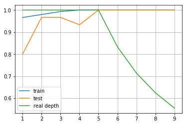

```python
plt.plot(max_depth, scores_train, label='train')
plt.plot(max_depth, scores_test, label='test')
plt.plot(max_depth, current_depth, label='real depth')

plt.legend(loc='best')
plt.grid()
plt.show()
```

### Замечания по случайному лесу

1. Число деревьев нужно подбирать, так как большое количество деревьев увеличивает качество на обучении, но на валидации, может быть меньше или не меняться вовсе, но время обучении возрастает.
2. Важным параметров является число признаков, которые участвуют в построении правила разделение. Для классификации обычно используется $\sqrt{n}$, а для регрессии $\frac{n}{3}$. Параметр является важным, так как при его увеличении деревья становятся похожими друг на друга.
3. Параметр глубины деревьев можно не подбирать, так как деревья сами настроивают эту высоту. Но если выборка слишком шумная, от рекомендуется не использовать слишком глубокие деревья.

P.S все параметры нужно подбирать на кросс-валидации.